# Klasyfikacja ocen przejazdów

Projekt z Eksploracji Danych

Autor

Igor Nowiński

# Cel badania

Celem badania jest zbudowanie optymalnego modelu klasyfikacyjnego, którego zadaniem będzie klasyfikacja oceny końcowej. Dzięki temu będziemy mogli określić czy dany przejazd możemy uznać za wzorowy, dobry czy zły.

# Opis zbioru danych

Zbiór danych został zebrany na podstawie aplikacji Go!Track. Jest on dostępny na stronie [Uniwersytetu Kalifornijskiego w Irvine](https://archive.ics.uci.edu/dataset/354/gps+trajectories). Aplikacja pełniła rolę nawigatora GPS oraz służyła do szukania przewoźników. Dostępna ona była w sklepie [Google Play](https://web.archive.org/web/20170719115511/https://play.google.com/store/apps/details?id=com.go.router). Zbiór danych posiada 163 obserwacje i składa się z 10 zmiennych.

[figure not shown]

`id_android` - numer identyfikacyjny urządzenia z którego pochodzą dane

`speed` - średnia prędkość pojazdy w kilometrach na godzinę

`distance` - dystans przejechany, liczony w kilometrach

`time` - czas podróży, liczony w godzinach

`rating` - zmienna nominalna, która przyjmuje 3 wartości. Jest to ogólna ocena przejazdu przez pasażera 1 - źle, 2 - w porządku, 3 - dobrze

`rating_bus` - zmienna nominalna, określa poziom zatłoczenia w pojeździe 1 - mało pasażerów, 2 - pojazd nie jest przepełniony, 3 - pojazd jest przepełniony

`rating_weather` - określa, jaka była pogoda podczas podróży 1 - deszczowo, 2 - słonecznie

`car_or_bus` - czy pasażer podróżował samochodem, czy autobusem 1 - samochód, 2 - autobus

`linha` - informacja na temat pojazdu

**Pokaż kod**

```r
head(df) %>%
  mutate(speed = round(speed,2),
         time = round(time,2),
         distance = round(distance, 2)) %>%
  gt()
```

Tabela 1: Przykładowe wartości zmiennych w zbiorze danych

| id | id_android | speed | time | distance | rating | rating_bus | rating_weather | car_or_bus | linha |
| --- | --- | --- | --- | --- | --- | --- | --- | --- | --- |
| 1 | 0 | 19.21 | 0.14 | 2.65 | 3 | 0 | 0 | 1 |  |
| 2 | 0 | 30.85 | 0.17 | 5.29 | 3 | 0 | 0 | 1 |  |
| 3 | 1 | 13.56 | 0.07 | 0.92 | 3 | 0 | 0 | 2 |  |
| 4 | 1 | 19.77 | 0.39 | 7.70 | 3 | 0 | 0 | 2 |  |
| 8 | 0 | 25.81 | 0.15 | 4.00 | 2 | 0 | 0 | 1 |  |
| 10 | 2 | 1.35 | 0.01 | 0.01 | 2 | 0 | 0 | 1 |  |

# Przygotowanie zbioru

Ponieważ zbiór danych zawiera identyfikatory, do przeprowadzenia analizy zdecydowałem się usunąć kolumny `id` i `id_android`. Dodatkowo usuwam również kolumnę `linha`, ponieważ jest typu *chr*. Zamieniam zmienne nominalne na typ *factor*.

### Nadmiarowość zmiennych

Zmienną`speed` można obliczyć ze wzoru poniżej, dlatego usuwam ją ze zbioru.

$$speed[\frac{Km}{h}] = \frac{distance[Km]}{time[h]}$$

Niestety zmienne `rating_bus` i `rating_weather` posiadają wiele wartości 0, co oznaczają braki danych. Zmieniłem poziomy *factor* tak, aby zaczynały się od zera.

**Pokaż kod**

```r
head(df) %>%
  mutate(time = round(time,2),
         distance = round(distance,2)) %>%
  gt()
```

Tabela 2: Przykładowe wartości zmiennych w zbiorze danych po usunięciu kolumn id, id_android, linha i konwersji typu danych

| time | distance | rating | rating_bus | rating_weather | car_or_bus |
| --- | --- | --- | --- | --- | --- |
| 0.14 | 2.65 | 2 | NA | NA | 0 |
| 0.17 | 5.29 | 2 | NA | NA | 0 |
| 0.07 | 0.92 | 2 | NA | NA | 1 |
| 0.39 | 7.70 | 2 | NA | NA | 1 |
| 0.15 | 4.00 | 1 | NA | NA | 0 |
| 0.01 | 0.01 | 1 | NA | NA | 0 |

Nowe wartości zmiennych nominalnych:

`rating_bus` 0 - mało pasażerów, 1 - pojazd nie jest przepełniony, 2 - pojazd jest przepełniony

`rating_weather` 0 - deszczowo, 1 - słonecznie

`car_or_bus` 0 - samochód, 1 - autobus

W Tabela 3 możemy zauważyć, że obserwacji w których pojazd był zatłoczony jest tylko 3. Zbiór nie jest zbalansowany, co może prowadzić do problemów przy uczeniu i sprawdzaniu modeli uczenia maszynowego.

**Pokaż kod**

```r
tabela_rating_bus <- as.data.frame(table(df$rating_bus))
colnames(tabela_rating_bus) <- c("Poziom", "Liczebność")
tabela_rating_bus %>% gt()
tabela_rating_weather <- as.data.frame(table(df$rating_weather))
colnames(tabela_rating_weather) <- c("Poziom", "Liczebność")
tabela_rating_weather %>% gt()
tabela_rating <- as.data.frame(table(df$rating))
colnames(tabela_rating) <- c("Poziom", "Liczebność")
tabela_rating %>% gt()
```

Tabela 3: Przedstawienie liczebności zmiennych nominalnych

(a) rating_bus

| Poziom | Liczebność |
| --- | --- |
| 0 | 34 |
| 1 | 10 |
| 2 | 3 |

(b) rating_weather

| Poziom | Liczebność |
| --- | --- |
| 0 | 10 |
| 1 | 37 |

(c) rating

| Poziom | Liczebność |
| --- | --- |
| 0 | 17 |
| 1 | 45 |
| 2 | 101 |

### Sprawdzenie braków danych

**Pokaż kod**

```r
braki <- as.data.frame(t(colSums(is.na(df))))
braki %>% gt()
```

Tabela 4: Sprawdzenie występowania wartości NA w zbiorze danych

| time | distance | rating | rating_bus | rating_weather | car_or_bus |
| --- | --- | --- | --- | --- | --- |
| 0 | 0 | 0 | 116 | 116 | 0 |

Stanowi to 71.17% obserwacji. Jest to bardzo dużo i logika podpowiada, że powinienem usunąć te dwie zmienne. Zdecydowałem natomiast o przeprowadzeniu imputacji danych, w celu zachowania obserwacji innych zmiennych. Wyniki będą porównane później.

### Imputacja danych

Ze względu na dużą ilość braków danych, zdecydowałem się imputować zmienne `rating_bus` i `rating_weather`. Użyłem do tego metody *rf* z biblioteki `mice`.

**Pokaż kod**

```r
head(imputation_rf$imp$rating_bus, 10) %>% gt()
head(imputation_rf$imp$rating_weather,10) %>% gt()
```

Tabela 5: Imputacja danych metodą rf

(a) rating_bus

| 1 | 2 | 3 | 4 | 5 |
| --- | --- | --- | --- | --- |
| 0 | 0 | 0 | 0 | 0 |
| 0 | 0 | 0 | 0 | 0 |
| 1 | 0 | 0 | 0 | 0 |
| 0 | 0 | 0 | 0 | 1 |
| 0 | 2 | 2 | 1 | 0 |
| 0 | 2 | 0 | 2 | 0 |
| 0 | 1 | 0 | 0 | 0 |
| 1 | 0 | 0 | 0 | 0 |
| 0 | 0 | 1 | 0 | 0 |
| 0 | 1 | 2 | 1 | 1 |

(b) rating_weather

| 1 | 2 | 3 | 4 | 5 |
| --- | --- | --- | --- | --- |
| 1 | 1 | 1 | 1 | 1 |
| 1 | 1 | 1 | 1 | 1 |
| 1 | 1 | 1 | 1 | 1 |
| 1 | 0 | 1 | 1 | 1 |
| 1 | 0 | 0 | 1 | 0 |
| 1 | 1 | 0 | 1 | 1 |
| 1 | 1 | 1 | 1 | 1 |
| 1 | 1 | 1 | 1 | 1 |
| 1 | 1 | 1 | 1 | 1 |
| 1 | 1 | 0 | 0 | 1 |

#### Porównanie imputowanych zbiorów

##### rating_bus

**imputacja 1**

**Pokaż kod**

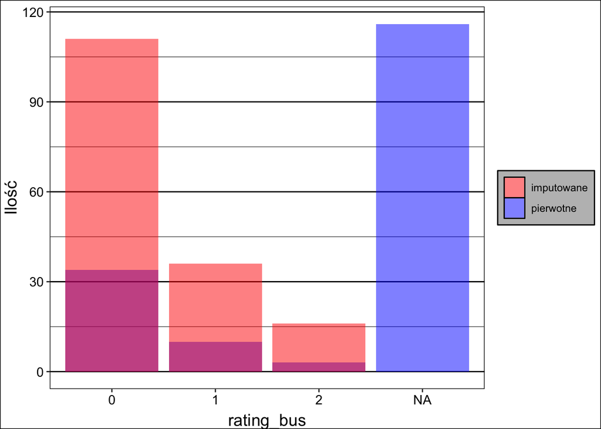

Rysunek 1: Rozkład obserwacji w klasach zmiennej rating_bus przy uzyciu 1 zbioru

```r
theme_set(theme_light())
ggplot() +
  geom_bar(data = df,
               aes(x = rating_bus, fill = "pierwotne"),
               alpha = 0.5) +
  geom_bar(data = imputation_1,
               aes(x=rating_bus, fill = "imputowane"),
               alpha = 0.5) +
  scale_fill_manual(values = c("pierwotne" = 'blue',
                               "imputowane" = 'red'),
                    name = "Legend") +
  labs(y = "Ilość")
```

**imputacja 2**

**Pokaż kod**

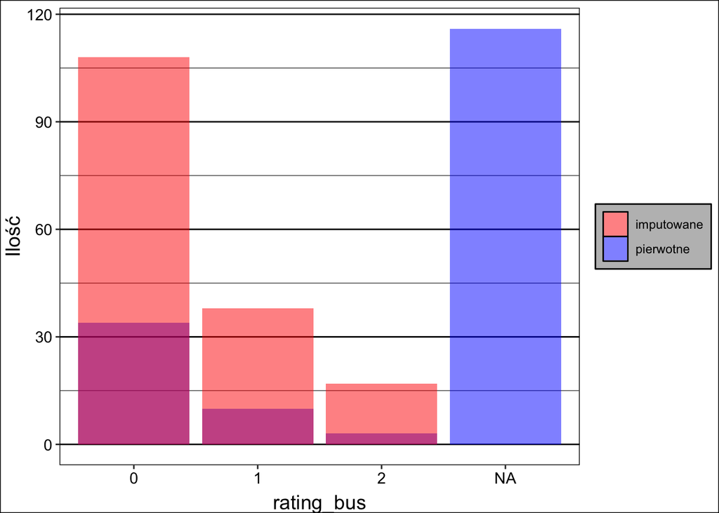

Rysunek 2: Rozkład obserwacji w klasach zmiennej rating_bus przy użyciu 2 zbioru

```r
theme_set(theme_light())
ggplot() +
  geom_bar(data = df,
               aes(x = rating_bus, fill = "pierwotne"),
               alpha = 0.5) +
  geom_bar(data = imputation_2,
               aes(x=rating_bus, fill = "imputowane"),
               alpha = 0.5) +
  scale_fill_manual(values = c("pierwotne" = 'blue',
                               "imputowane" = 'red'),
                    name = "Legend") +
  labs(y = "Ilość")
```

**imputacja 3**

**Pokaż kod**

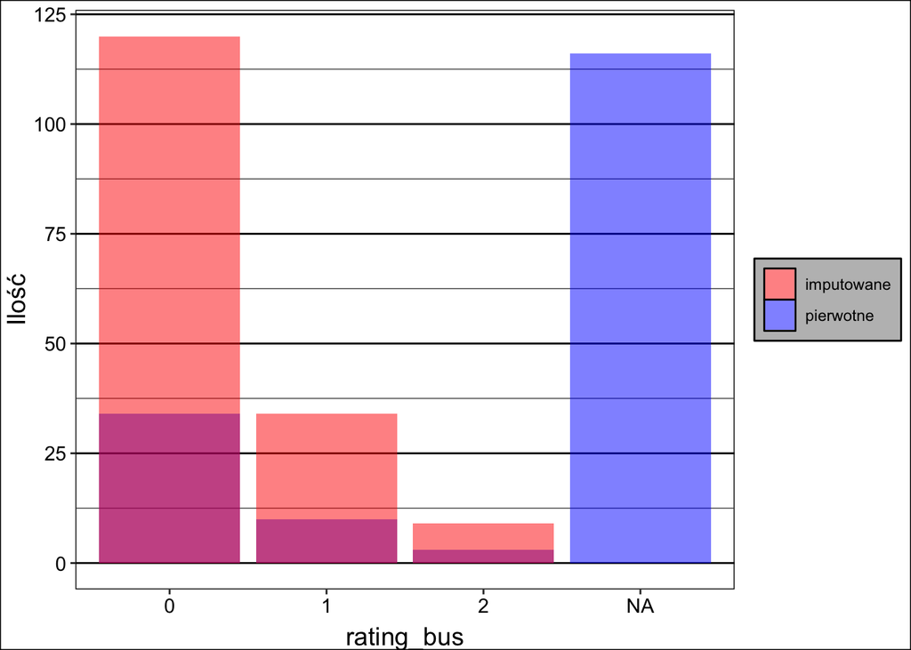

Rysunek 3: Rozkład obserwacji w klasach zmiennej rating_bus przy użyciu 3 zbioru

```r
theme_set(theme_light())
ggplot() +
  geom_bar(data = df,
               aes(x = rating_bus, fill = "pierwotne"),
               alpha = 0.5) +
  geom_bar(data = imputation_3,
               aes(x=rating_bus, fill = "imputowane"),
               alpha = 0.5) +
  scale_fill_manual(values = c("pierwotne" = 'blue',
                               "imputowane" = 'red'),
                    name = "Legend") +
  labs(y = "Ilość")
```

**imputacja 4**

**Pokaż kod**

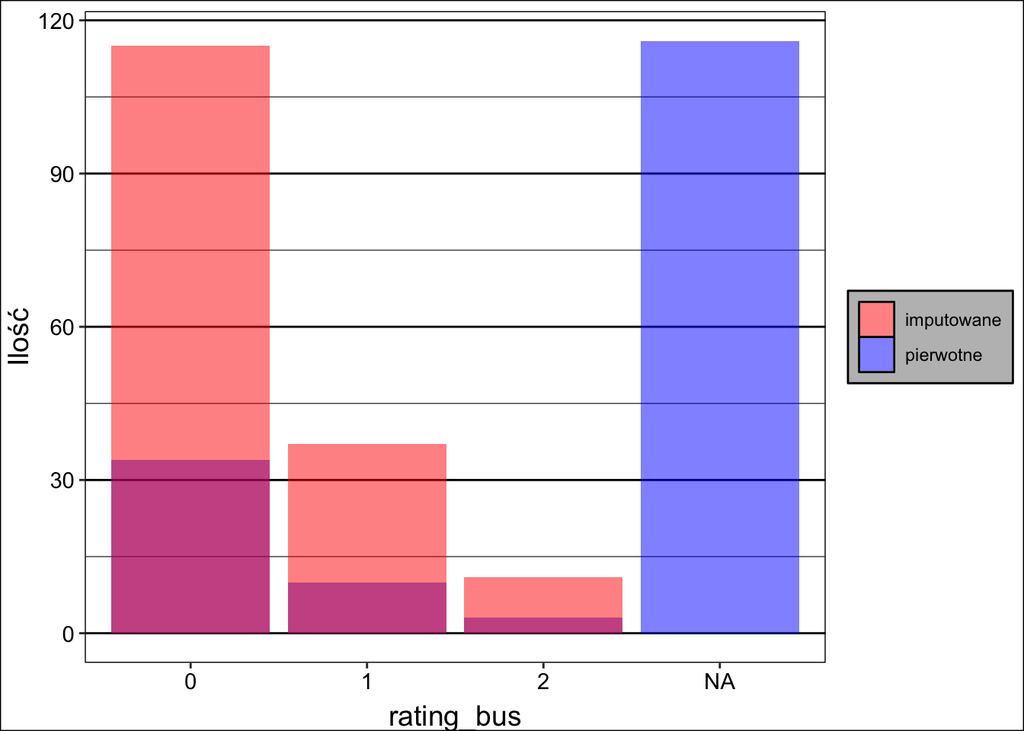

Rysunek 4: Rozkład obserwacji w klasach zmiennej rating_bus przy użyciu 4 zbioru

```r
theme_set(theme_light())
ggplot() +
  geom_bar(data = df,
               aes(x = rating_bus, fill = "pierwotne"),
               alpha = 0.5) +
  geom_bar(data = imputation_4,
               aes(x=rating_bus, fill = "imputowane"),
               alpha = 0.5) +
  scale_fill_manual(values = c("pierwotne" = 'blue',
                               "imputowane" = 'red'),
                    name = "Legend") +
  labs(y = "Ilość")
```

**imputacja 5**

**Pokaż kod**

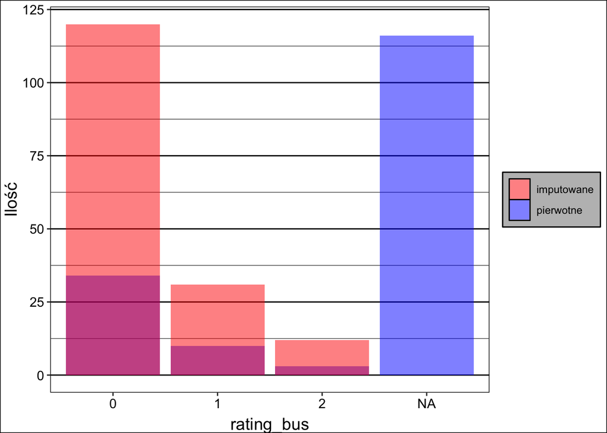

Rysunek 5: Rozkład obserwacji w klasach zmiennej rating_bus przy użyciu 5 zbioru

```r
theme_set(theme_light())
ggplot() +
  geom_bar(data = df,
               aes(x = rating_bus, fill = "pierwotne"),
               alpha = 0.5) +
  geom_bar(data = imputation_5,
               aes(x=rating_bus, fill = "imputowane"),
               alpha = 0.5) +
  scale_fill_manual(values = c("pierwotne" = 'blue',
                               "imputowane" = 'red'),
                    name = "Legend") +
  labs(y = "Ilość")
```

##### rating_weather

**imputacja 1**

**Pokaż kod**

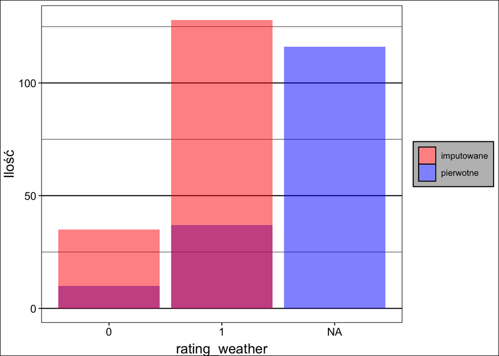

Rysunek 6: Rozkład obserwacji w klasach zmiennej rating_weather przy użyciu 1 zbioru

```r
ggplot() +
  geom_bar(data = df,
               aes(x = rating_weather, fill = "pierwotne"),
               alpha = 0.5) +
  geom_bar(data = imputation_1,
               aes(x=rating_weather, fill = "imputowane"),
               alpha = 0.5) +
  scale_fill_manual(values = c("pierwotne" = 'blue',
                               "imputowane" = 'red'),
                    name = "Legend") +
  labs(y = "Ilość")
```

**imputacja 2**

**Pokaż kod**

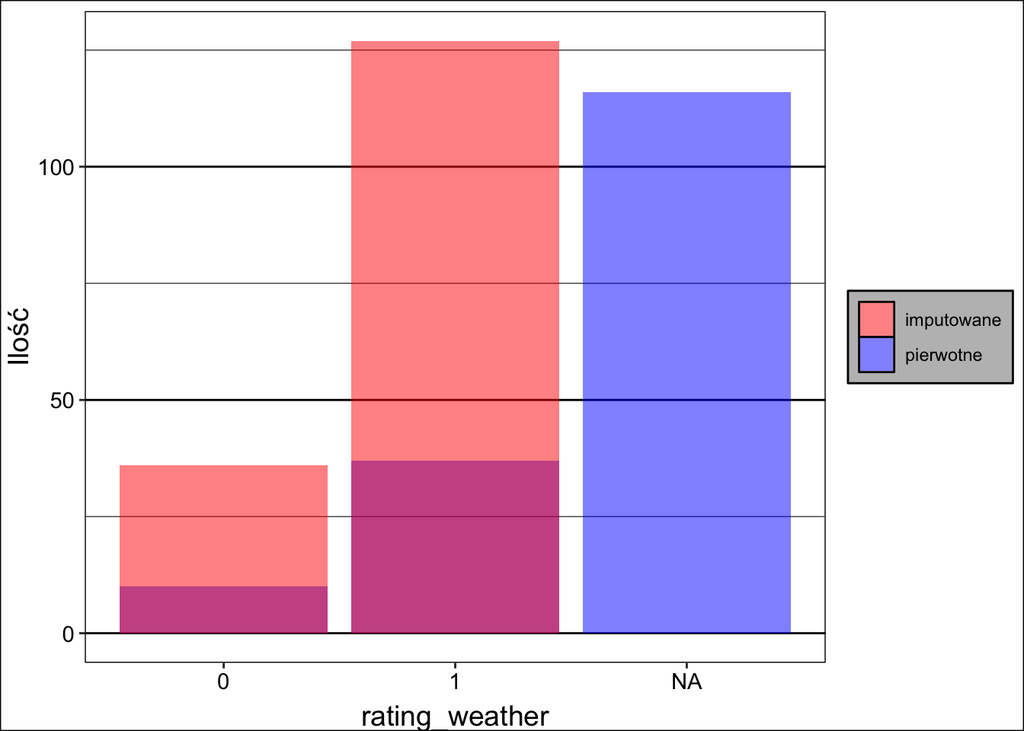

Rysunek 7: Rozkład obserwacji w klasach zmiennej rating_weather przy użyciu 2 zbioru

```r
ggplot() +
  geom_bar(data = df,
               aes(x = rating_weather, fill = "pierwotne"),
               alpha = 0.5) +
  geom_bar(data = imputation_2,
               aes(x=rating_weather, fill = "imputowane"),
               alpha = 0.5) +
  scale_fill_manual(values = c("pierwotne" = 'blue',
                               "imputowane" = 'red'),
                    name = "Legend") +
  labs(y = "Ilość")
```

**imputacja 3**

**Pokaż kod**

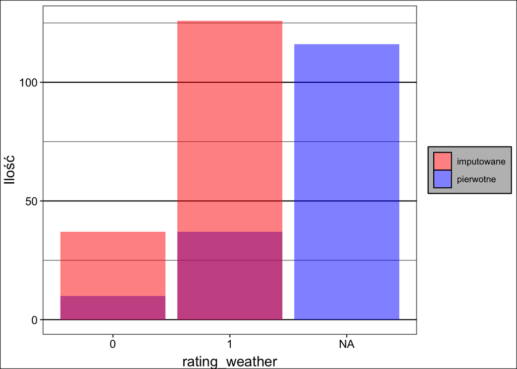

Rysunek 8: Rozkład obserwacji w klasach zmiennej rating_weather przy użyciu 3 zbioru

```r
ggplot() +
  geom_bar(data = df,
               aes(x = rating_weather, fill = "pierwotne"),
               alpha = 0.5) +
  geom_bar(data = imputation_3,
               aes(x=rating_weather, fill = "imputowane"),
               alpha = 0.5) +
  scale_fill_manual(values = c("pierwotne" = 'blue',
                               "imputowane" = 'red'),
                    name = "Legend") +
  labs(y = "Ilość")
```

**imputacja 4**

**Pokaż kod**

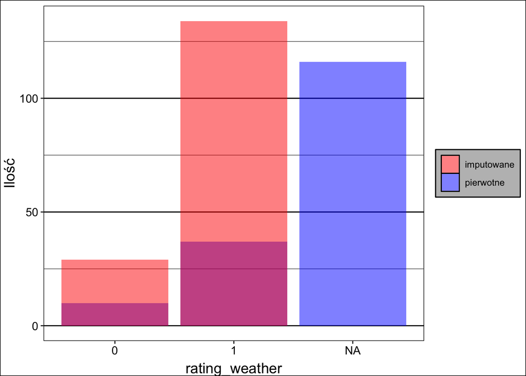

Rysunek 9: Rozkład obserwacji w klasach zmiennej rating_weather przy użyciu 4 zbioru

```r
ggplot() +
  geom_bar(data = df,
               aes(x = rating_weather, fill = "pierwotne"),
               alpha = 0.5) +
  geom_bar(data = imputation_4,
               aes(x=rating_weather, fill = "imputowane"),
               alpha = 0.5) +
  scale_fill_manual(values = c("pierwotne" = 'blue',
                               "imputowane" = 'red'),
                    name = "Legend") +
  labs(y = "Ilość")
```

**imputacja 5**

**Pokaż kod**

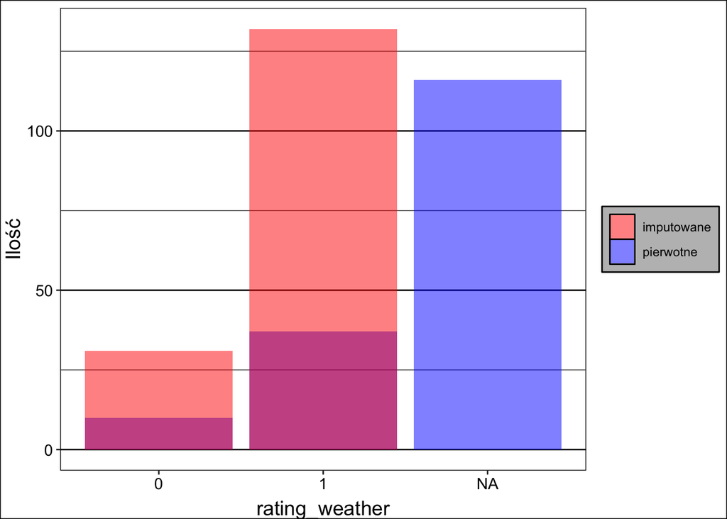

Rysunek 10: Rozkład obserwacji w klasach zmiennej rating_weather przy użyciu 5 zbioru

```r
ggplot() +
  geom_bar(data = df,
               aes(x = rating_weather, fill = "pierwotne"),
               alpha = 0.5) +
  geom_bar(data = imputation_5,
               aes(x=rating_weather, fill = "imputowane"),
               alpha = 0.5) +
  scale_fill_manual(values = c("pierwotne" = 'blue',
                               "imputowane" = 'red'),
                    name = "Legend") +
  labs(y = "Ilość")
```

**Pokaż kod**

```r
as.data.frame(t(wariancje)) %>%
  mutate(rating_bus = round(rating_bus,2),
         rating_weather = round(rating_weather,2)) %>%
  gt(rownames_to_stub = T)
```

Tabela 6: Wariancja imputacji rating_bus i rating_weather

|  | rating_bus | rating_weather |
| --- | --- | --- |
| Zbiór 1 | 0.48 | 0.17 |
| Zbiór 2 | 0.50 | 0.18 |
| Zbiór 3 | 0.32 | 0.18 |
| Zbiór 4 | 0.37 | 0.14 |
| Zbiór 5 | 0.38 | 0.15 |

Na podstawie wyników zamieszczonych w Tabela 6 wybieram zbiór imputowany przez *rf* w wersji 3.

# Wizualizacja zbioru danych

**distance**

**Pokaż kod**

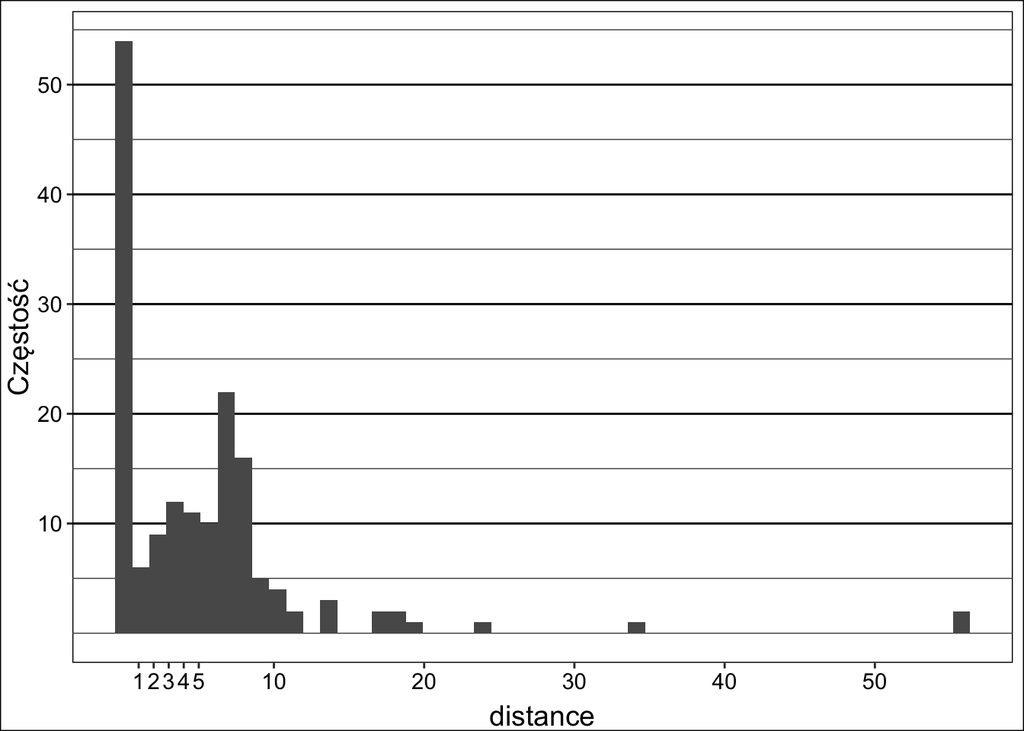

Rysunek 11: Rozkład częstotliwości występowania wartości zmiennej distance

```r
imputation_completed %>%
ggplot(aes(distance)) + geom_histogram(bins = 50) +
  scale_x_continuous(breaks = c(1,2,3,4,5,10,20,30,40,50)) +
  scale_y_continuous(breaks = c(10,20,30,40,50)) +
  labs(x = "distance",
       y = "Częstość")
```

Średni pokonany dystans wynosi 5.3 Km, natomiast mediana 4 Km.

**time**

**Pokaż kod**

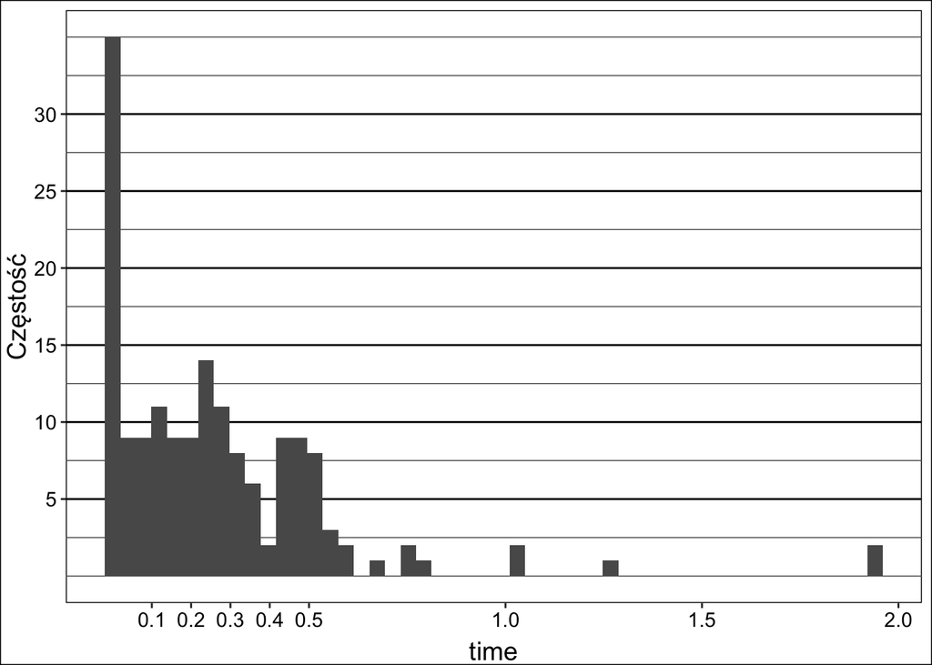

```r
imputation_completed %>%
ggplot(aes(time)) + geom_histogram(bins = 50) +
  scale_x_continuous(breaks = c(0.1,0.2,0.3,0.4,0.5, 1, 1.5, 2)) +
  scale_y_continuous(breaks = c(5,10,15,20,25,30)) +
  labs(x = "time",
       y = "Częstość")
```

Średnia czasu przejazdu wynosi 0.26 h, natomiast mediana 0.21 h.

Korelacja pomiędzy `distance` i `time` jest równa 0.66. Jest to zrozumiałe, ponieważ w sytuacji długiego dystansu do pokonania również rośnie potrzebny czas.

## Sprawdzenie zależności pomiędzy zmiennymi nominalnymi

**car_or_bus vs rating_bus**

**Pokaż kod**

```r
chisq.test(imputation_completed$car_or_bus, imputation_completed$rating_bus)
```

```
    Pearson's Chi-squared test

data:  imputation_completed$car_or_bus and imputation_completed$rating_bus
X-squared = 3.723, df = 2, p-value = 0.1554
```

**Pokaż kod**

```r
fisher.test(imputation_completed$car_or_bus, imputation_completed$rating_bus)
```

```
    Fisher's Exact Test for Count Data

data:  imputation_completed$car_or_bus and imputation_completed$rating_bus
p-value = 0.1768
alternative hypothesis: two.sided
```

Na podstawie testu $\chi^2$ i Fishera nie mam powodów do odrzucenia $H_0$ o braku zależności pomiędzy `car_or_bus` i `rating_bus`.

Oceny pojazdów nie są zależne od wyboru samochodu lub autokaru.

**car_or_bus vs rating_weather**

**Pokaż kod**

```r
chisq.test(imputation_completed$car_or_bus, imputation_completed$rating_weather)
```

```
    Pearson's Chi-squared test with Yates' continuity correction

data:  imputation_completed$car_or_bus and imputation_completed$rating_weather
X-squared = 1.4826, df = 1, p-value = 0.2234
```

**Pokaż kod**

```r
fisher.test(imputation_completed$car_or_bus, imputation_completed$rating_weather)
```

```
    Fisher's Exact Test for Count Data

data:  imputation_completed$car_or_bus and imputation_completed$rating_weather
p-value = 0.191
alternative hypothesis: true odds ratio is not equal to 1
95 percent confidence interval:
 0.2618078 1.3174486
sample estimates:
odds ratio
 0.5921559
```

Na podstawie testu $\chi^2$ i Fishera nie mam powodów do odrzucenia $H_0$ o braku zależności pomiędzy `car_or_bus` i `rating_weather`.

Wybór typu pojazdu nie jest zależny od pogody.

# Budowa modeli klasyfikacyjnych

Dzielę zbiór na część treningową i testową. Dodatkowo zastosowałem upsampling, aby zbalansować zbiór.

Użyłem siatek regularnych do wybrania optymalnych parametrów modeli.

Do walidacji dopasowania wybrałem walidację krzyżową.

**Podział oryginalnego zbioru danych**

```r
set.seed(2024)
split_df <- initial_split(df[,c(-4,-5)])
train_df <- training(split_df)
test_df <- testing(split_df)

train_df_upsampled <- upSample(x = train_df[,-3],
  y = train_df$rating, yname = 'rating')
```

**Podział imputowanego zbioru danych**

```r
set.seed(2024)
split <- initial_split(imputation_completed, prop = .7)
train <- training(split)
test <- testing(split)

train_upsampled <- upSample(x = train[,-3],
  y = train$rating, yname = 'rating')
```

### Deklaracje, uczenie oraz sprawdzenie modeli

**Las losowy z usunięciem zmiennych**

**Pokaż kod**

```r
set.seed(2024)
rec <- recipe(rating ~ ., data = train_df_upsampled)
rf <- rand_forest(mode = "classification",
                  mtry = tune(),
                  min_n= tune(),
                  trees = tune()) %>%
  set_engine("ranger")

control_settings <- control_grid(save_pred = TRUE)
wflow <- workflow() %>%
  add_recipe(rec) %>%
  add_model(rf)

param <- extract_parameter_set_dials(wflow)

param <- param %>% update(mtry = mtry(c(1,3)))

grid <- grid_regular(param, levels = 5)

metrics <- metric_set(bal_accuracy, accuracy)

cv <- vfold_cv(train_df_upsampled, v = 10, repeats = 5)

tuning <- tune_grid(
  object = wflow,
  grid = grid,
  resamples = cv,
  metrics = metrics,
  control = control_settings)

final_wflow <- finalize_workflow(wflow, show_best(tuning)[1,])

wflow_fit <- fit(final_wflow, data = train_df_upsampled)

pred_test <- predict(wflow_fit, test_df)

cm <- pred_test %>%
  bind_cols(test_df) %>%
  conf_mat(truth = rating, estimate = .pred_class)
```

**Las losowy**

**Pokaż kod**

```r
set.seed(2024)
rec <- recipe(rating ~ ., data = train_upsampled)

rf <- rand_forest(mode = "classification",
                  mtry = tune(),
                  min_n= tune(),
                  trees = tune()) %>%
  set_engine("ranger")

control_settings <- control_grid(save_pred = TRUE)
wflow <- workflow() %>%
  add_recipe(rec) %>%
  add_model(rf)

param <- extract_parameter_set_dials(wflow)

param <- param %>% update(mtry = mtry(c(1,5)))

grid <- grid_regular(param, levels = 5)

cv <- vfold_cv(train_upsampled, v = 10, repeats = 5)

metrics <- metric_set(accuracy, bal_accuracy)

tuning <- tune_grid(
  object = wflow,
  grid = grid,
  resamples = cv,
  metrics = metrics,
  control = control_settings)

final_wflow <- finalize_workflow(wflow,
  show_best(tuning, metric = 'accuracy')[1,])

wflow_fit <- fit(final_wflow, data = train_upsampled)

pred_test <- predict(wflow_fit, test)

cm_rf <- pred_test %>%
  bind_cols(test) %>%
  conf_mat(truth = rating, estimate = .pred_class)
```

**XGBoost**

**Pokaż kod**

```r
set.seed(2024)
rec <- recipe(rating ~ ., data = train_upsampled) %>%
  step_dummy(all_nominal(), -rating)

boost <- boost_tree(mode = "classification",
                  mtry = tune(),
                  min_n= tune(),
                  trees = tune(),
                  learn_rate = tune(),
                  loss_reduction = tune(),
                  tree_depth = tune()) %>%
  set_engine("xgboost")

control_settings <- control_grid(save_pred = TRUE)
wflow <- workflow() %>%
  add_recipe(rec) %>%
  add_model(boost)

param <- extract_parameter_set_dials(wflow)

param <- param %>% update(mtry = mtry(c(1,5)))

grid <- grid_regular(param, levels = 2)

cv <- vfold_cv(train_upsampled, v = 10, repeats = 5)

metrics <- metric_set(accuracy, bal_accuracy)
tuning <- tune_grid(
  object = wflow,
  grid = grid,
  resamples = cv,
  metrics = metrics,
  control = control_settings)

final_wflow <- finalize_workflow(wflow,
  show_best(tuning, metric = 'accuracy')[1,])

wflow_fit <- fit(final_wflow, data = train_upsampled)

pred_test <- predict(wflow_fit, test)

cm_boost <- pred_test %>%
  bind_cols(test) %>%
  conf_mat(truth = rating, estimate = .pred_class)
```

**SVM**

**Pokaż kod**

```r
set.seed(2024)
rec <- recipe(rating ~ ., data = train_upsampled)

svm <- svm_rbf(cost = tune(), rbf_sigma = tune()) %>%
  set_engine("kernlab") %>%
  set_mode("classification")

control_settings <- control_grid(save_pred = TRUE)
wflow <- workflow() %>%
  add_recipe(rec) %>%
  add_model(svm)

param <- extract_parameter_set_dials(wflow)

grid <- grid_regular(param, levels = 6)

cv <- vfold_cv(train_upsampled, v = 10, repeats = 5)

metrics <- metric_set(accuracy, bal_accuracy)

tuning <- tune_grid(
  object = wflow,
  grid = grid,
  resamples = cv,
  metrics = metrics,
  control = control_settings)

final_wflow <- finalize_workflow(wflow,
  show_best(tuning, metric = 'accuracy')[1,])

wflow_fit <- fit(final_wflow, data = train_upsampled)

pred_test <- predict(wflow_fit, test)

cm_svm <- pred_test %>%
  bind_cols(test) %>%
  conf_mat(truth = rating, estimate = .pred_class)
```

# Podsumowanie i wnioski

Po dopasowaniu modeli do zbioru treningowego oraz sprawdzeniu ich na zbiorze testowym uzyskałem wyniki, które przedstawiłem poniżej.

### Macierze konfuzji

**Las losowy z usunięciem zmiennych**

**Pokaż kod**

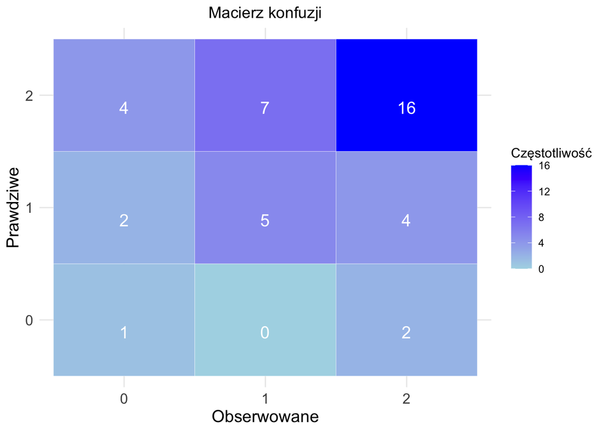

Rysunek 13: Macierz konfuzji lasu losowego na oryginalnym zbiorze danych

```r
DataFrame_cm <- as.data.frame(cm$table)
names(DataFrame_cm) <- c("Truth", "Prediction", "Częstotliwość")

# Visualization
ggplot(DataFrame_cm, aes(x = Truth, y = Prediction, fill = Częstotliwość)) +
  geom_tile(color = "white") +
  geom_text(aes(label = Częstotliwość), vjust = 1.5, color = "white", size = 5) +
  scale_fill_gradient(low = "lightblue", high = "blue") +
  labs(title = "Macierz konfuzji", x = "Obserwowane",
       y = "Prawdziwe") +
  theme_minimal() +
  theme(axis.text = element_text(size = 12),
        axis.title = element_text(size = 14),
        plot.title = element_text(hjust = 0.5))
```

**Las losowy**

**Pokaż kod**

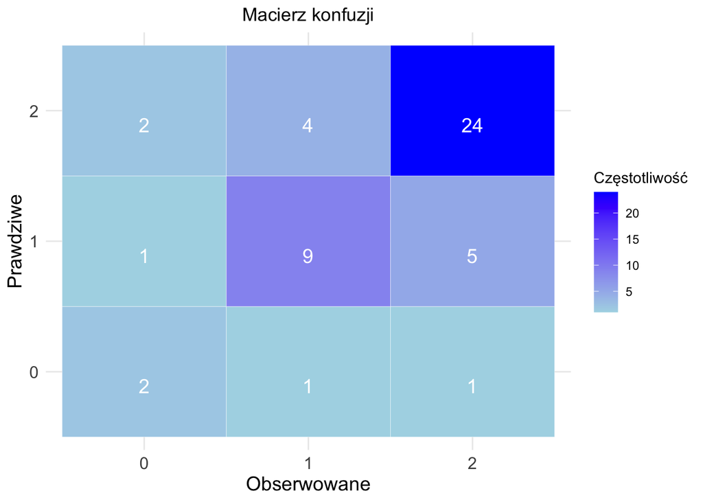

Rysunek 14: Macierz konfuzji lasu losowego na imputowanym zbiorze danych

```r
DataFrame_cm <- as.data.frame(cm_rf$table)
names(DataFrame_cm) <- c("Truth", "Prediction", "Częstotliwość")

# Visualization
ggplot(DataFrame_cm, aes(x = Truth, y = Prediction, fill = Częstotliwość)) +
  geom_tile(color = "white") +
  geom_text(aes(label = Częstotliwość), vjust = 1.5, color = "white", size = 5) +
  scale_fill_gradient(low = "lightblue", high = "blue") +
  labs(title = "Macierz konfuzji", x = "Obserwowane",
       y = "Prawdziwe") +
  theme_minimal() +
  theme(axis.text = element_text(size = 12),
        axis.title = element_text(size = 14),
        plot.title = element_text(hjust = 0.5))
```

**XGBoost**

**Pokaż kod**

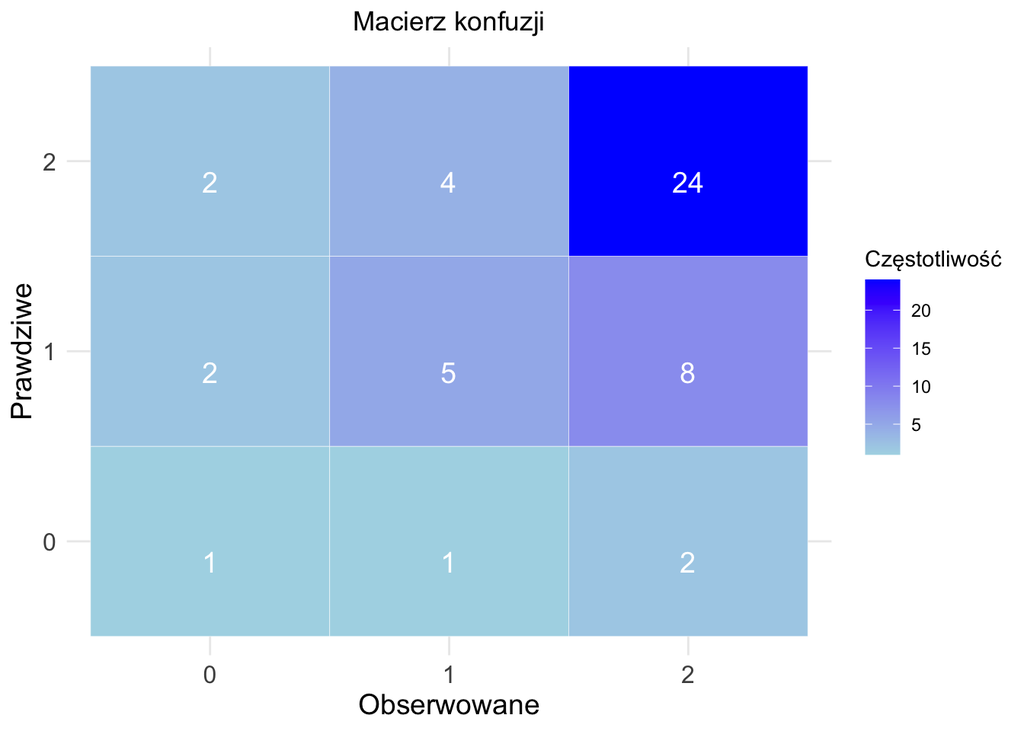

Rysunek 15: Macierz konfuzji boostingu

```r
DataFrame_cm <- as.data.frame(cm_boost$table)
names(DataFrame_cm) <- c("Truth", "Prediction", "Częstotliwość")

# Visualization
ggplot(DataFrame_cm, aes(x = Truth, y = Prediction, fill = Częstotliwość)) +
  geom_tile(color = "white") +
  geom_text(aes(label = Częstotliwość), vjust = 1.5, color = "white", size = 5) +
  scale_fill_gradient(low = "lightblue", high = "blue") +
  labs(title = "Macierz konfuzji", x = "Obserwowane",
       y = "Prawdziwe") +
  theme_minimal() +
  theme(axis.text = element_text(size = 12),
        axis.title = element_text(size = 14),
        plot.title = element_text(hjust = 0.5))
```

**SVM**

**Pokaż kod**

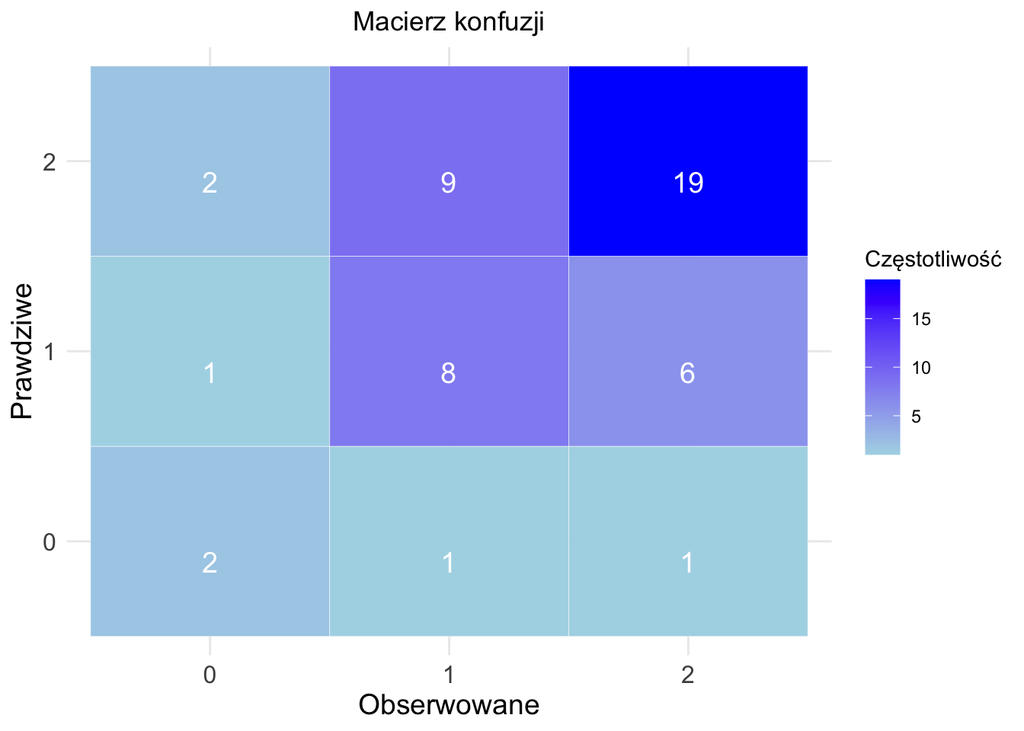

Rysunek 16: Macierz konfuzji SVM

```r
DataFrame_cm <- as.data.frame(cm_svm$table)
names(DataFrame_cm) <- c("Truth", "Prediction", "Częstotliwość")

# Visualization
ggplot(DataFrame_cm, aes(x = Truth, y = Prediction, fill = Częstotliwość)) +
  geom_tile(color = "white") +
  geom_text(aes(label = Częstotliwość), vjust = 1.5, color = "white", size = 5) +
  scale_fill_gradient(low = "lightblue", high = "blue") +
  labs(title = "Macierz konfuzji", x = "Obserwowane",
       y = "Prawdziwe") +
  theme_minimal() +
  theme(axis.text = element_text(size = 12),
        axis.title = element_text(size = 14),
        plot.title = element_text(hjust = 0.5))
```

### Metryki wyników na zbiorze testowym

**Pokaż kod**

```r
wyniki_test <- cbind(sum_cm$.estimate, sum_cm_rf$.estimate, sum_cm_boost$.estimate, sum_cm_svm$.estimate)
wyniki_test <- as.data.frame(matrix(sapply(wyniki_test, round, 2), byrow = F, ncol = 4))
colnames(wyniki_test) <- c("rf", "imputowany rf", "xgboost", "svm")
rownames(wyniki_test) <- sum_cm$.metric
wyniki_test %>% gt(rownames_to_stub = T)
```

Tabela 7: Metryki modeli na zbiorze testowym

|  | rf | imputowany rf | xgboost | svm |
| --- | --- | --- | --- | --- |
| accuracy | 0.54 | 0.71 | 0.61 | 0.59 |
| kap | 0.17 | 0.46 | 0.23 | 0.26 |
| sens | 0.46 | 0.63 | 0.46 | 0.56 |
| spec | 0.73 | 0.82 | 0.75 | 0.76 |
| bal_accuracy | 0.59 | 0.73 | 0.60 | 0.66 |

Na podstawie wyników możemy stwierdzić, że najlepiej dopasował się model lasu losowego na imputowanym zbiorze. Wszystkie podane w Tabela 7 metryki są dla niego najwyższe. XGBoost i SVM wypadły gorzej, natomiast lepiej niż pierwotny model lasu.

Warto również zaznaczyć, że przez małą liczebność obserwacji, wyniki nie są stabilne - zmiana jądra generatora może je kompletnie zmienić.

# Źródła

- [Zbiór danych](https://archive.ics.uci.edu/dataset/354/gps+trajectories)

### Wykorzystane biblioteki

- `rio`
- `doParallel`
- `tidyverse`
- `dplyr`
- `gt`
- `naniar`
- `tidymodels`
- `yardstick`
- `themis`
- `caret`